# Bimbo EDA

Alexandru Papiu

June 20, 2016

The Bimbo competition:

### Read and Clean:

Let’s first load the packages and read in the data:

```r
library(data.table)
library(dplyr)
library(ggplot2)
library(knitr)
```

```r
train = fread("/Users/alexpapiu/Documents/Data/Bimbo/train.csv",
              select = c("Semana", "Agencia_ID", "Canal_ID", "Ruta_SAK",
                         "Cliente_ID", "Producto_ID", "Demanda_uni_equil"),
              colClasses = c(Semana = "numeric", Agencia_ID = "character",
                             Canal_ID = "character", Ruta_SAK = "character",
                             Cliente_ID = "character", Producto_ID = "character",
                             Demanda_uni_equil = "numeric"),
              showProgress = FALSE,
              nrows = 1e6)


#n = 10e6 #number of rows to be subsetted
#set.seed(423)
#sam = sample(1:nrow(train), n)
#train = train[sam]

kable(sample_n(train, 5))
```

| Semana | Agencia_ID | Canal_ID | Ruta_SAK | Cliente_ID | Producto_ID | Demanda_uni_equil |
| --- | --- | --- | --- | --- | --- | --- |
| 3 | 1122 | 1 | 1445 | 608436 | 1309 | 2 |
| 3 | 1127 | 1 | 1417 | 4256871 | 32819 | 14 |
| 3 | 1117 | 1 | 1058 | 676788 | 2233 | 3 |
| 3 | 1123 | 1 | 2804 | 339224 | 36748 | 7 |
| 3 | 1123 | 1 | 1225 | 1269950 | 1242 | 6 |

So we have 6 features and the response variable `Demanda_uni_equil` which is continuous.

Really all of our features other than semana (week) are categorical but are encoded as integer ID’s - this might trip up visualization packages so we tell data.table to read them in as characters. We could have also changed them to factors but a lot of them have many unique values and factors with many levels are unwieldly sometimes.

Let’s see how many different unique values we have for each feature:

```r
sapply(train, function(x)length(unique(x)))
```

```
##            Semana        Agencia_ID          Canal_ID          Ruta_SAK
##                 1                18                 6               613
##        Cliente_ID       Producto_ID Demanda_uni_equil
##             58794               512               586
```

Phew quite a few have lots of levels - we’ll see how to deal with this later.

For now let’s explore the Demand variable for a bit:

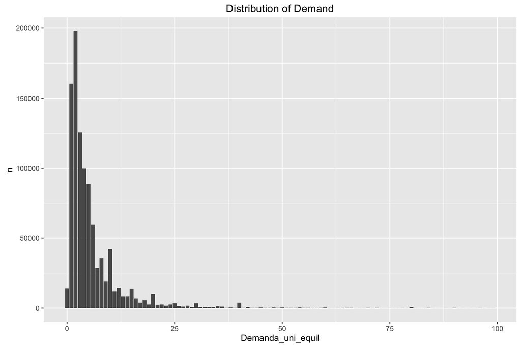

```r
train %>%
    count(Demanda_uni_equil) %>%
    filter(Demanda_uni_equil < 100) %>%
    ggplot(aes(x = Demanda_uni_equil, y = n)) +
        geom_bar(stat = "identity") +
        ggtitle("Distribution of Demand")
```

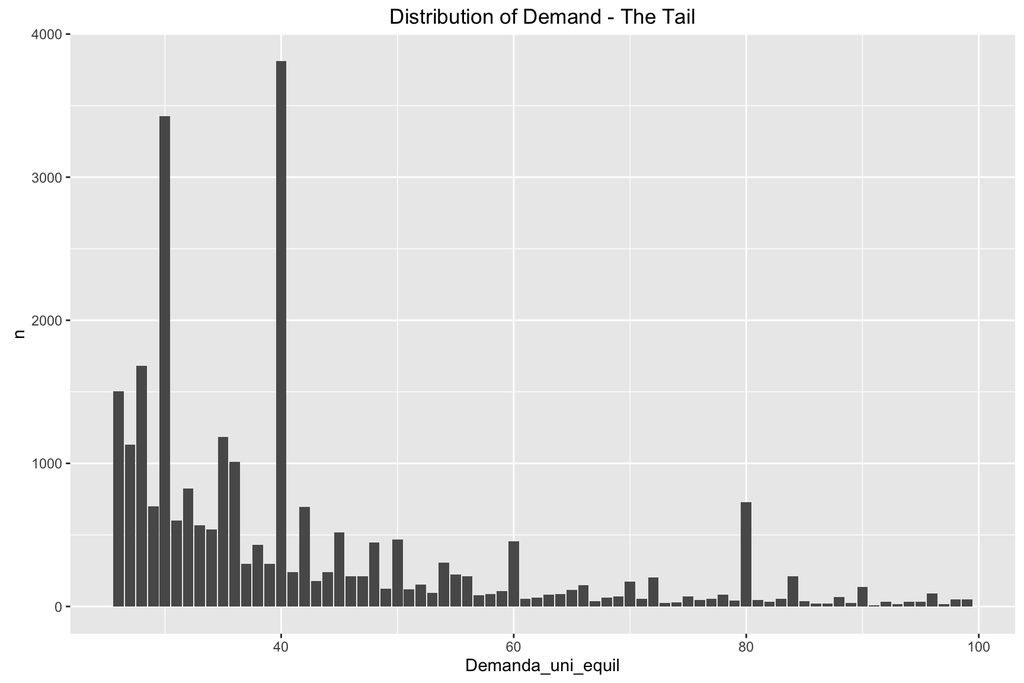

```r
train %>%
    count(Demanda_uni_equil) %>%
    filter(Demanda_uni_equil > 25, Demanda_uni_equil < 100) %>%
    ggplot(aes(x = Demanda_uni_equil, y = n)) +
        geom_bar(stat = "identity") +
        ggtitle("Distribution of Demand - The Tail")
```

Hmmm..very interesting - certain “round” values - 40, 60, 80 are much more common as demands.

### A look at the features:

I’d like to know more about the relation between different features and the demand. All of the features are categorical and a lot of them have hundreds or thousands of levels so this will pose some challanges.

#### Producto_ID:

We have a total of 512 Product ID’s - waay to many to visualize at once. For starters let’s just look at the most popular products:

```r
train %>% count(Producto_ID, sort = TRUE) -> product_count
top_products = product_count$Producto_ID[1:12]
```

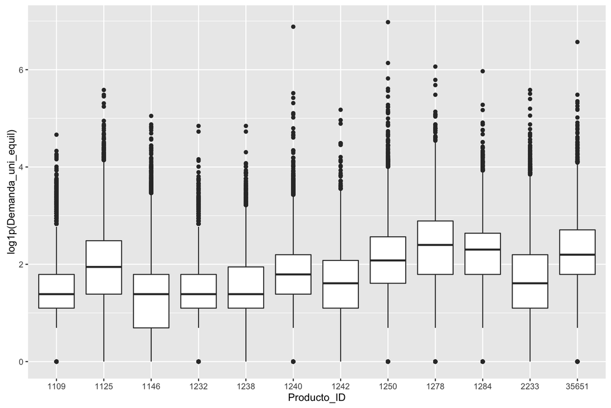

```r
train %>%
    filter(Producto_ID %in% top_products) %>%
    ggplot(aes(x = Producto_ID, y = log1p(Demanda_uni_equil))) +
    geom_boxplot()
```

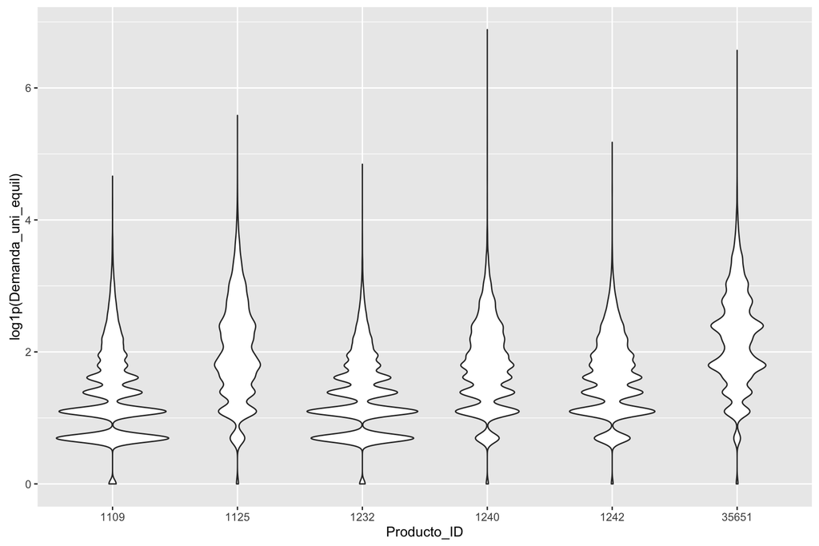

```r
train %>%
    filter(Producto_ID %in% top_products[4:9]) %>%
    ggplot(aes(x = Producto_ID, y = log1p(Demanda_uni_equil))) +
    geom_violin()
```

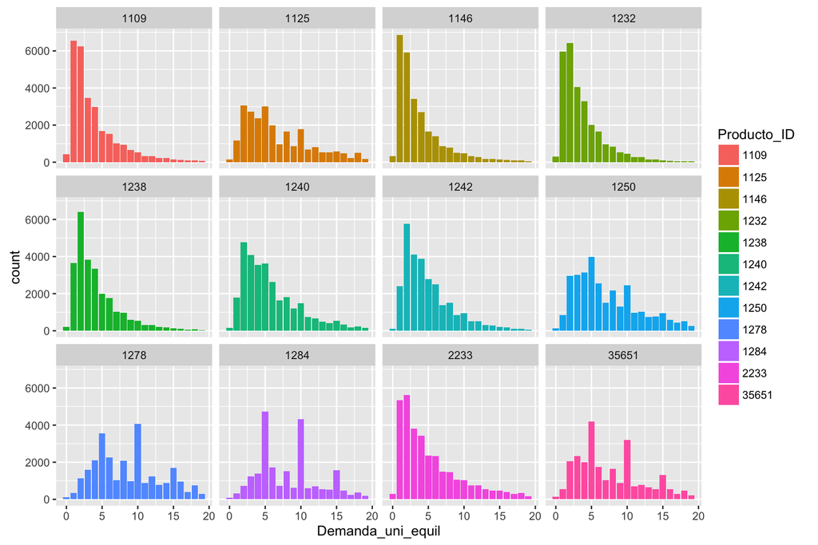

```r
train %>%
    filter(Producto_ID %in% top_products) %>%
    filter(Demanda_uni_equil < 20) %>%
    ggplot(aes(x = Demanda_uni_equil, fill = Producto_ID)) +
    geom_bar() +
    facet_wrap( ~ Producto_ID)
```

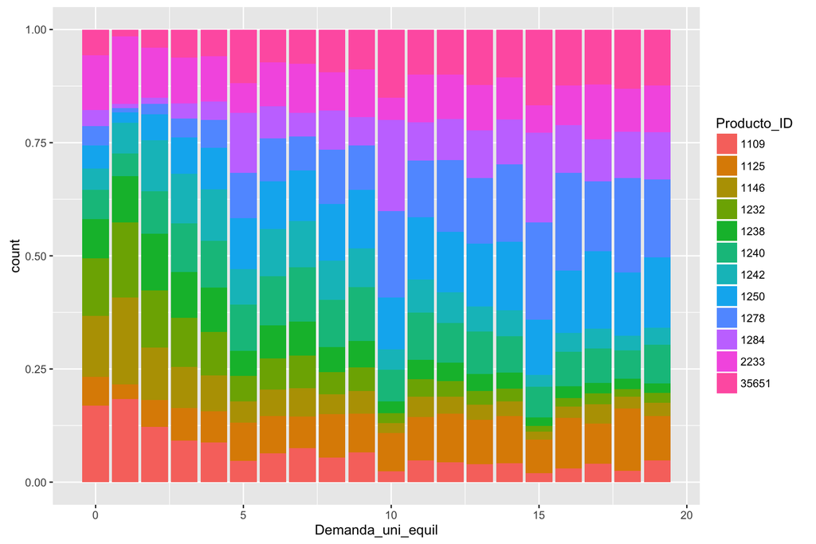

```r
train %>%
    filter(Producto_ID %in% top_products) %>%
    filter(Demanda_uni_equil < 20) %>%
    ggplot(aes(x = Demanda_uni_equil, fill = Producto_ID)) +
    geom_bar(position = "fill")
```

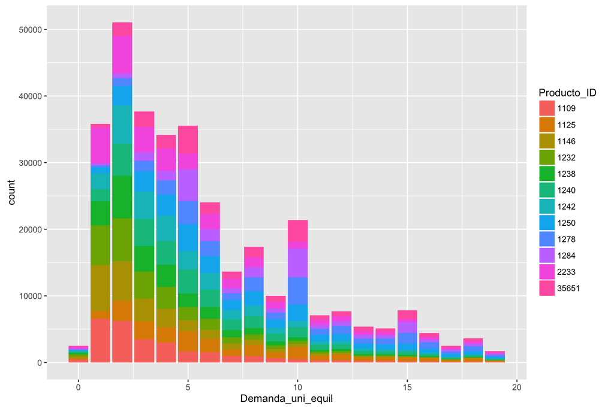

```r
train %>%
    filter(Producto_ID %in% top_products) %>%
    filter(Demanda_uni_equil < 20) %>%
    ggplot(aes(x = Demanda_uni_equil, fill = Producto_ID)) +
    geom_bar(position = "stack")
```